# Cardiac maturation process from human iPSCs

## Summary

To improve the maturity of iPSC-cardiomyocytes, we addressed the cell type specification of iPSC-cardiomyocytes by microarray and analyzed in detail about cardiac maturation process. We compared gene expression between samples, and extracted several key genes for cardiac maturation and check the function of these genes. We show that a number of genes expression correlate with the cardiac maturation process, and found surface markers to discriminate differentiated cardiomyocytes from other immature cells.

## Overall design

it consists of mRNA profiles of differentiated iPSC-cardiomyocytes at several differentiation stages. Additionally, we checked the function of several important genes for cardiac maturation, which were extracted from microarray data.

## Experiments

After cardiac differentiation, we collected GFP positive cardiomyocytes by FACS sorting on day9, 21, and 30. Additionally, we compared differences of gene expressions between CORIN highly expressed cardiomyocytes and low expressed cardiomyocytes. Moreover, we checked the effects of HDAC2 for cardiac maturation.

```r
targets <- read.csv("targets.txt", sep="")
```

```r
expressions <- read.delim("GSE72611_series_matrix_expressions.txt", header=TRUE,row.names = 1)
```

```r
dim(expressions)
```

```
## [1] 42545    17
```

```r
summary(expressions)
```

```
##    GSM1866367       GSM1866368       GSM1866369       GSM1866370
##  Min.   : 1.980   Min.   : 1.454   Min.   : 1.697   Min.   : 1.235
##  1st Qu.: 3.428   1st Qu.: 3.090   1st Qu.: 3.057   1st Qu.: 2.838
##  Median : 6.133   Median : 5.874   Median : 5.981   Median : 5.840
##  Mean   : 6.493   Mean   : 6.283   Mean   : 6.318   Mean   : 6.153
##  3rd Qu.: 8.910   3rd Qu.: 8.910   3rd Qu.: 8.910   3rd Qu.: 8.910
##  Max.   :19.914   Max.   :19.274   Max.   :19.150   Max.   :18.566
##    GSM1866371       GSM1866372       GSM1866373       GSM1866374
##  Min.   : 1.413   Min.   : 1.477   Min.   : 1.682   Min.   : 1.724
##  1st Qu.: 2.967   1st Qu.: 2.795   1st Qu.: 2.678   1st Qu.: 2.482
##  Median : 5.994   Median : 5.882   Median : 5.742   Median : 5.745
##  Mean   : 6.246   Mean   : 6.206   Mean   : 6.212   Mean   : 6.187
##  3rd Qu.: 8.910   3rd Qu.: 8.910   3rd Qu.: 8.910   3rd Qu.: 8.910
##  Max.   :18.870   Max.   :18.775   Max.   :19.034   Max.   :18.824
##    GSM1866375       GSM1866376       GSM1866377       GSM1866378
##  Min.   : 2.620   Min.   : 2.914   Min.   : 2.785   Min.   : 2.868
##  1st Qu.: 2.984   1st Qu.: 3.288   1st Qu.: 3.118   1st Qu.: 3.201
##  Median : 5.757   Median : 5.825   Median : 5.768   Median : 5.778
##  Mean   : 6.370   Mean   : 6.491   Mean   : 6.407   Mean   : 6.446
##  3rd Qu.: 8.910   3rd Qu.: 8.910   3rd Qu.: 8.910   3rd Qu.: 8.910
##  Max.   :18.728   Max.   :18.221   Max.   :18.458   Max.   :18.155
##    GSM1866379       GSM1866380       GSM1866381       GSM1866382
##  Min.   : 2.943   Min.   : 1.912   Min.   : 2.564   Min.   : 2.906
##  1st Qu.: 3.327   1st Qu.: 2.641   1st Qu.: 3.052   1st Qu.: 3.252
##  Median : 5.842   Median : 5.811   Median : 5.873   Median : 5.765
##  Mean   : 6.511   Mean   : 6.222   Mean   : 6.436   Mean   : 6.462
##  3rd Qu.: 8.910   3rd Qu.: 8.910   3rd Qu.: 8.910   3rd Qu.: 8.910
##  Max.   :18.296   Max.   :18.524   Max.   :18.514   Max.   :18.458
##    GSM1866383
##  Min.   : 2.435
##  1st Qu.: 2.815
##  Median : 5.749
##  Mean   : 6.324
##  3rd Qu.: 8.910
##  Max.   :18.249
```

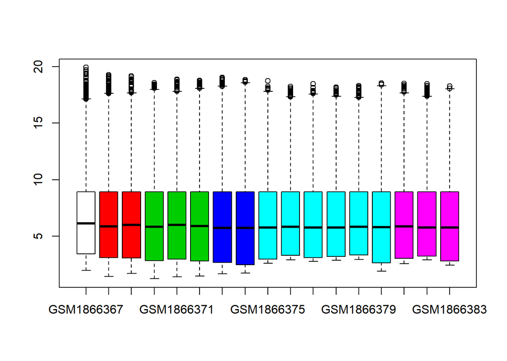

```r
boxplot(expressions, col = c(0,2,2,3,3,3,4,4,5,5,5,5,5,5,6,6,6))
```

First we convert our expressions data frame to a matrix

```r
expressionValues <- data.matrix(expressions)
```

We add information about our experiment

```r
myInfo=list(myName="Aleix Brugada", myLab="Omics Lab",
            myContact="aleix.brugada@alum.esci.upf.edu", myTitle="Cardiac maturation process from human iPSCs")
show(myInfo)
```

```
## $myName
## [1] "Aleix Brugada"
##
## $myLab
## [1] "Omics Lab"
##
## $myContact
## [1] "aleix.brugada@alum.esci.upf.edu"
##
## $myTitle
## [1] "Cardiac maturation process from human iPSCs"
```

```r
myGenes <-  rownames(expressions)
```

We load Biobase

```r
require(Biobase)
```

We start constructing our Expression Set

```r
myEset <- ExpressionSet(expressionValues)
class(myEset)
```

```
## [1] "ExpressionSet"
## attr(,"package")
## [1] "Biobase"
```

```r
show(myEset)
```

```
## ExpressionSet (storageMode: lockedEnvironment)
## assayData: 42545 features, 17 samples
##   element names: exprs
## protocolData: none
## phenoData: none
## featureData: none
## experimentData: use 'experimentData(object)'
## Annotation:
```

We construct an Annotated data frame

```r
columnDesc <-  data.frame(labelDescription= c("SAMPLE_NAMES", "DAY","Cell Type", "Experiment Type"))
myAnnotDF <- new("AnnotatedDataFrame", data=targets, varMetadata= columnDesc)
show(myAnnotDF)
```

```
## An object of class 'AnnotatedDataFrame'
##   rowNames: 1 2 ... 17 (17 total)
##   varLabels: SAMPLE_NAME DAY cell_type Experiment
##   varMetadata: labelDescription
```

We define our Annotated data frame as the phenoData of our Expression Set

```r
phenoData(myEset) <- myAnnotDF
```

```r
rownames(pData(myAnnotDF))<-as.character(pData(myAnnotDF)$SAMPLE_NAME)
myEset <- ExpressionSet(assayData=expressionValues, phenoData=myAnnotDF)
show(myEset)
```

```
## ExpressionSet (storageMode: lockedEnvironment)
## assayData: 42545 features, 17 samples
##   element names: exprs
## protocolData: none
## phenoData
##   sampleNames: GSM1866367 GSM1866368 ... GSM1866383 (17 total)
##   varLabels: SAMPLE_NAME DAY cell_type Experiment
##   varMetadata: labelDescription
## featureData: none
## experimentData: use 'experimentData(object)'
## Annotation:
```

Now Our expression set has expressionValues as assayData and the Annotated data frame as phenoData

```r
myEset <- ExpressionSet(assayData=expressionValues,
                        phenoData=myAnnotDF,
                        featureNames =myGenes)
# show(myEset)
```

We can also store information about the experiment with another class called MIAME

```r
myDesc <- new("MIAME", name= myInfo[["myName"]],
              lab= myInfo[["myLab"]],
              contact= myInfo[["myContact"]] ,
              title=myInfo[["myTitle"]])
print(myDesc)
```

```
## Experiment data
##   Experimenter name: Aleix Brugada
##   Laboratory: Omics Lab
##   Contact information: aleix.brugada@alum.esci.upf.edu
##   Title: Cardiac maturation process from human iPSCs
##   URL:
##   PMIDs:
##   No abstract available.
```

We add this information to our Expression Set

```r
myEset <- ExpressionSet(assayData=expressionValues,
                        phenoData=myAnnotDF,
                        featureNames =myGenes,
                        experimentData = myDesc)
 show(myEset)
```

```
## ExpressionSet (storageMode: lockedEnvironment)
## assayData: 42545 features, 17 samples
##   element names: exprs
## protocolData: none
## phenoData
##   sampleNames: GSM1866367 GSM1866368 ... GSM1866383 (17 total)
##   varLabels: SAMPLE_NAME DAY cell_type Experiment
##   varMetadata: labelDescription
## featureData: none
## experimentData: use 'experimentData(object)'
## Annotation:
```

We can also subset our Expression Set. Here we only want the information from before day 30 of experimentation.

```r
youngEset <- myEset[,pData(myEset)$DAY!='day30']
dim(exprs(youngEset))
```

```
## [1] 42545     5
```

```r
head(pData(youngEset))
```

|  | SAMPLE_NAME | DAY | cell_type | Experiment |
| --- | --- | --- | --- | --- |
| GSM1866367 | GSM1866367 | day0 | UD | - |
| GSM1866368 | GSM1866368 | day3 | D | - |
| GSM1866369 | GSM1866369 | day5 | D | - |
| GSM1866370 | GSM1866370 | day9 | CMs | - |
| GSM1866371 | GSM1866371 | day21 | CMs | - |

All this process can be shortened by using GEOquery

```r
if (!require(GEOquery)) {
  BiocManager::install("GEOquery")
}
```

```
## Setting options('download.file.method.GEOquery'='auto')
```

```
## Setting options('GEOquery.inmemory.gpl'=FALSE)
```

```r
require(GEOquery)
gse <- getGEO("GSE72611")
```

```
## Found 1 file(s)
```

```
## GSE72611_series_matrix.txt.gz
```

```
## File stored at:
```

```
## C:\Users\usuari\AppData\Local\Temp\RtmpqqztVw/GPL14550.soft
```

```r
class(gse)
```

```
## [1] "list"
```

```r
names(gse)
```

```
## [1] "GSE72611_series_matrix.txt.gz"
```

```r
gse[[1]]
```

```
## ExpressionSet (storageMode: lockedEnvironment)
## assayData: 42545 features, 17 samples
##   element names: exprs
## protocolData: none
## phenoData
##   sampleNames: GSM1866367 GSM1866368 ... GSM1866383 (17 total)
##   varLabels: title geo_accession ... gender:ch1 (38 total)
##   varMetadata: labelDescription
## featureData
##   featureNames: (+)E1A_r60_1 (+)E1A_r60_3 ... GE_BrightCorner
##     (42545 total)
##   fvarLabels: ID SPOT_ID ... SEQUENCE (17 total)
##   fvarMetadata: Column Description labelDescription
## experimentData: use 'experimentData(object)'
## Annotation: GPL14550
```

```r
esetFromGEO <- gse[[1]]
```